# Mundial de natación de Kazán 2015

4to mates

2024-10-11

# Introducción

El conjunto de datos obtenidos abarca los resultados del Campeonato Mundial de Natación Kazán 2015, con los correspondientes datos de cada nadador y prueba.

Los datos han sido extraídos de [Omega](http://www.omegatiming.com/File/Download?id=00010F0200FFFFFFFFFFFFFFFFFFFF08), la plataforma oficial de tiempos de la World Aquatics.

El conjunto de datos contiene información sobre los nadadores (fecha de nacimiento, país, id), y sobre la prueba nadada (tiempo de reacción, parciales, tiempo total, estilo, serie).

Según la descripción oficial de los datos, las variables que conforman el conjunto de datos son:

- athleteid: id del nadador (único)
- lastname: Apellidos del nadador
- firstname: El nombre del nadador
- birthdate: Fecha de nacimiento del nadador
- gender: Género del nadador/a
- name: Nombre del país
- code: abreviatura del país.
- eventid: id de la prueba nadada (único)
- heat: Serie en la que nadaron
- lane: Calle en la que nadaron (0 a 9)
- points: puntos FINA que realizaron. (es una “estimación” entre el mejor tiempo o récord del mundo, y el tiempo realizado. )
- reactiontime: Tiempo de reacción en la salida.
- swimtime: tiempo tardado
- split: Parcial
- cumswimtime: Tiempo acumulado en el parcial
- splitdistance: Distancia del parcial
- daytime: hora a la que se nadó
- round: ronda (preliminar, semifinal, final)
- distance: distancia de la prueba
- relaycount: Número de relevista.
- stroke: Estilo de nado en el que se realizó la prueba.
- splitswimtime: Tiempo del parcial (50m)

# Entender los datos.

Primeramente, vamos a leer los datos:

```r
datos2015<-read.csv("datos/2015_FINA.csv", header=TRUE, sep = ',')
```

Una vez nuestro programa los ha leído, vamos a echar nuestro primer vistazo:

```r
dim(datos2015)
```

```
## [1] 11423    22
```

Tenemos en total 11423 filas y 22 variables o columnas.

Veámos la primera ocurrencia de nuestra tabla:

```r
head(datos2015,1)
```

```
##   athleteid lastname firstname  birthdate gender    name code eventid heat lane
## 1    100784   BORSHI      NOEL 1996-02-13      F Albania  ALB       1    1    4
##   points reactiontime swimtime split cumswimtime splitdistance daytime round
## 1    680         0.77    63.65     1       29.63            50     930   PRE
##   distance relaycount stroke splitswimtime
## 1      100          1    FLY         29.63
```

Observamos Noel Borshi, nadadora albanesa nacida un 13 de febrero de 1996, que tiene como id el número (100784). Noel Borshi nadó la prueba 1 en la serie 1 y carril 4. Nadó el 100m Mariposa en la ronda preliminar con un tiempo final de 63.65s y pasó por el primer parcial (50m) en 29.63 segundos.

# Análisis exploratorio de datos

## Resumen de los datos.

A continuación, vamos a ver un resumen de los datos:

```r
summary(datos2015)
```

```
##    athleteid        lastname          firstname          birthdate
##  Min.   :100392   Length:11423       Length:11423       Length:11423
##  1st Qu.:101501   Class :character   Class :character   Class :character
##  Median :103266   Mode  :character   Mode  :character   Mode  :character
##  Mean   :106980
##  3rd Qu.:110718
##  Max.   :125573
##
##     gender              name               code              eventid
##  Length:11423       Length:11423       Length:11423       Min.   :  1.00
##  Class :character   Class :character   Class :character   1st Qu.: 13.00
##  Mode  :character   Mode  :character   Mode  :character   Median : 30.00
##                                                           Mean   : 53.15
##                                                           3rd Qu.: 39.00
##                                                           Max.   :428.00
##
##       heat            lane           points        reactiontime
##  Min.   : 1.00   Min.   :0.000   Min.   :  52.0   Min.   :0.4200
##  1st Qu.: 1.00   1st Qu.:2.000   1st Qu.: 783.0   1st Qu.:0.6800
##  Median : 3.00   Median :4.000   Median : 853.0   Median :0.7200
##  Mean   : 3.08   Mean   :4.485   Mean   : 826.6   Mean   :0.7205
##  3rd Qu.: 4.00   3rd Qu.:7.000   3rd Qu.: 902.0   3rd Qu.:0.7600
##  Max.   :12.00   Max.   :9.000   Max.   :1028.0   Max.   :0.9700
##                                  NA's   :71       NA's   :61
##     swimtime           split         cumswimtime      splitdistance
##  Min.   :  21.19   Min.   : 1.000   Min.   :  21.19   Min.   :  50.0
##  1st Qu.: 114.10   1st Qu.: 1.000   1st Qu.:  49.45   1st Qu.:  50.0
##  Median : 231.31   Median : 3.000   Median :  99.36   Median : 150.0
##  Mean   : 366.11   Mean   : 6.296   Mean   : 197.01   Mean   : 314.8
##  3rd Qu.: 523.24   3rd Qu.: 8.000   3rd Qu.: 255.23   3rd Qu.: 400.0
##  Max.   :1137.27   Max.   :30.000   Max.   :1137.27   Max.   :1500.0
##  NA's   :59                         NA's   :59
##     daytime        round              distance        relaycount
##  Min.   : 930   Length:11423       Min.   :  50.0   Min.   :1
##  1st Qu.:1000   Class :character   1st Qu.: 200.0   1st Qu.:1
##  Median :1048   Mode  :character   Median : 400.0   Median :1
##  Mean   :1192                      Mean   : 580.5   Mean   :1
##  3rd Qu.:1117                      3rd Qu.: 800.0   3rd Qu.:1
##  Max.   :1943                      Max.   :1500.0   Max.   :1
##
##     stroke          splitswimtime
##  Length:11423       Min.   : 21.19
##  Class :character   1st Qu.: 29.10
##  Mode  :character   Median : 30.82
##                     Mean   : 31.02
##                     3rd Qu.: 32.77
##                     Max.   :101.02
##                     NA's   :59
```

De aquí, podemos obsevar que tenemos algunos valores nulos (NA’s), además se puede observar que, durante toda la competición, como máximo hubo 12 series y como mínimo 1. Que la piscina disponía de 10 carriles numerados del 0 al 9. También observamos que se nadaron pruebas de 50 y hasta 1500 metros.

Observamos que tenemos algunas variables categóricas, luego vamos a cargar la libreria “dyplr” y vamos a intentar visualizarlas de una mejor manera:

```r
datos2015<- datos2015 %>% convert_as_factor(gender,name,code,round,heat,lane,stroke)
```

Bien, ahora, visualicemos otra vez el resumen:

```r
summary(datos2015)
```

```
##    athleteid        lastname          firstname          birthdate
##  Min.   :100392   Length:11423       Length:11423       Length:11423
##  1st Qu.:101501   Class :character   Class :character   Class :character
##  Median :103266   Mode  :character   Mode  :character   Mode  :character
##  Mean   :106980
##  3rd Qu.:110718
##  Max.   :125573
##
##  gender              name           code         eventid            heat
##  F:5236   United States: 755   USA    : 755   Min.   :  1.00   1      :3181
##  M:6187   China        : 507   CHN    : 507   1st Qu.: 13.00   2      :2297
##           Australia    : 479   AUS    : 479   Median : 30.00   3      :1838
##           Great Britain: 462   GBR    : 462   Mean   : 53.15   4      :1561
##           Germany      : 411   GER    : 411   3rd Qu.: 39.00   5      :1317
##           Italy        : 382   ITA    : 382   Max.   :428.00   6      : 439
##           (Other)      :8427   (Other):8427                    (Other): 790
##       lane          points        reactiontime       swimtime
##  4      :1303   Min.   :  52.0   Min.   :0.4200   Min.   :  21.19
##  6      :1269   1st Qu.: 783.0   1st Qu.:0.6800   1st Qu.: 114.10
##  5      :1247   Median : 853.0   Median :0.7200   Median : 231.31
##  2      :1246   Mean   : 826.6   Mean   :0.7205   Mean   : 366.11
##  3      :1215   3rd Qu.: 902.0   3rd Qu.:0.7600   3rd Qu.: 523.24
##  7      :1202   Max.   :1028.0   Max.   :0.9700   Max.   :1137.27
##  (Other):3941   NA's   :71       NA's   :61       NA's   :59
##      split         cumswimtime      splitdistance       daytime     round
##  Min.   : 1.000   Min.   :  21.19   Min.   :  50.0   Min.   : 930   FIN:1475
##  1st Qu.: 1.000   1st Qu.:  49.45   1st Qu.:  50.0   1st Qu.:1000   PRE:8904
##  Median : 3.000   Median :  99.36   Median : 150.0   Median :1048   SEM:1022
##  Mean   : 6.296   Mean   : 197.01   Mean   : 314.8   Mean   :1192   SOP:   4
##  3rd Qu.: 8.000   3rd Qu.: 255.23   3rd Qu.: 400.0   3rd Qu.:1117   SOS:  18
##  Max.   :30.000   Max.   :1137.27   Max.   :1500.0   Max.   :1943
##                   NA's   :59
##     distance        relaycount    stroke     splitswimtime
##  Min.   :  50.0   Min.   :1    BACK  :1053   Min.   : 21.19
##  1st Qu.: 200.0   1st Qu.:1    BREAST:1205   1st Qu.: 29.10
##  Median : 400.0   Median :1    FLY   :1095   Median : 30.82
##  Mean   : 580.5   Mean   :1    FREE  :6782   Mean   : 31.02
##  3rd Qu.: 800.0   3rd Qu.:1    MEDLEY:1288   3rd Qu.: 32.77
##  Max.   :1500.0   Max.   :1                  Max.   :101.02
##                                              NA's   :59
```

Bien, ahora podemos observar muchas más cosas, observamos que las variables name y code toman absolutamente los mismos valores, luego seguramente podamos reducir en una variable el conjunto de datos. Vemos también que se nadaron pruebas de espalda, braza, mariposa, crol y estilos Individual. También observamos que las pruebas las disputaron hombres y mujeres. Podemos observar tamibén que el menor tiempo de reacción fue de 0.42 y el mayor de 0.97.

Viendo los datos, observamos que cada nadador tiene en una prueba concreta, tantas filas como parciales tenía en esa prueba, luego es obvio que para conocer mejor algunas variables, vamos a necesitar limpiar los datos para que los elementos repetidos no nos estorben.

## Estudio sobre el número de nadadores, su género, país y edad.

### Edad

Lo primero que vamos a hacer, va a ser crear una nueva variable, llamada edad, ya que birthdate no nos va a dar tanto juego.

```r
datos2015$birthdate <- as.Date(datos2015$birthdate)
#Calculamos la edad
fechaKazan<- as.Date("2015-07-24")
datos2015$edad <- as.numeric(difftime(fechaKazan, datos2015$birthdate, units = "weeks")) %/% 52  # Convertir de semanas a años
```

Ahora, vamos a crear una nueva tabla en la cual vamos a obtener sólamente los nadadores (sin repetir) que participaron en la competición:

```r
nadadoresParticipantes <- datos2015 %>%
  distinct(athleteid, .keep_all = TRUE)
```

Bien, ahora, vamos a observar qué sucede con las edades:

```r
summary(nadadoresParticipantes$edad)
```

```
##    Min. 1st Qu.  Median    Mean 3rd Qu.    Max.
##   10.00   19.00   21.00   21.32   24.00   38.00
```

Observamos que la edad máxima fue de 38 años, la media fue de 21.32 años, y el participante con menos edad fue de 10 años.

Aquí un enlace a la [noticia](https://www.rtve.es/deportes/20150807/nina-10-anos-alzain-tareq-asombra-a-natacion-mundial/1195782.shtml#:~:text=Se%20llama%20Alzain%20Tareq%2C%20tiene,estrella%20medi%C3%A1tica%20de%20la%20jornada.) sobre la joven nadadora de 10 años.

Podríamos echar un vistazo y ver si la noticia se refiere a los datos que tenemos:

```r
datos_edad_10 <- datos2015[datos2015$edad == 10, ]
datos_edad_10
```

```
##      athleteid lastname firstname  birthdate gender    name code eventid heat
## 1353    114036    TAREQ    ALZAIN 2005-04-14      F Bahrain  BRN      29    1
## 1354    114036    TAREQ    ALZAIN 2005-04-14      F Bahrain  BRN      34    1
##      lane points reactiontime swimtime split cumswimtime splitdistance daytime
## 1353    2    226         0.74    41.13     1       41.13            50     954
## 1354    6    291         0.72    35.78     1       35.78            50     930
##      round distance relaycount stroke splitswimtime edad
## 1353   PRE       50          1    FLY         41.13   10
## 1354   PRE       50          1   FREE         35.78   10
```

Se trata de una nadadora de Bahrain que nadó el 50 mariposa y el 50 libres.

Veámos como se distribuye en una gráfica de densidad las edades:

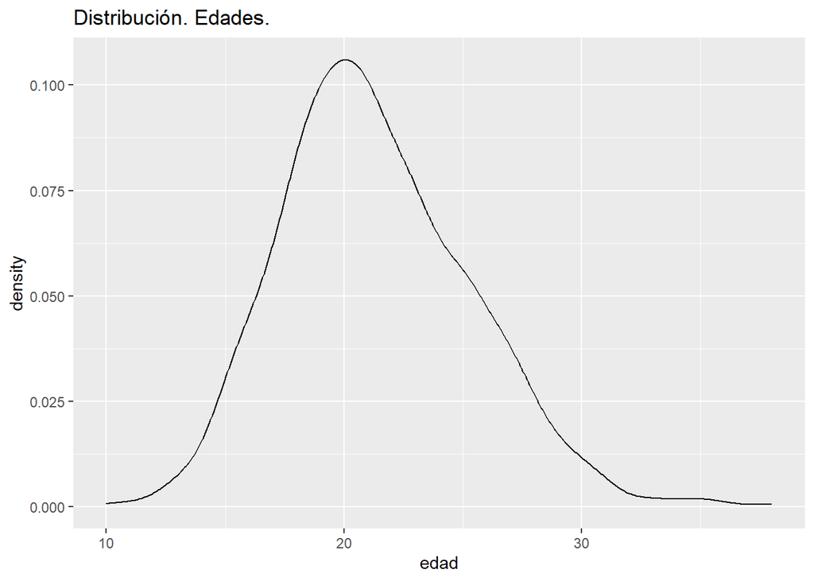

```r
ggplot(nadadoresParticipantes, aes(x = edad)) +
geom_density() +
ggtitle("Distribución. Edades.")
```

Observamos que se concentra casi todas las edades entre los 16 y los 27 aproximadamente.

### Géneros participantes.

Veamos el número exacto de mujeres y hombres en la competición:

```r
summary(nadadoresParticipantes$gender)
```

```
##   F   M
## 494 616
```

Luego, observamos que hay 616 hombres y 494 mujeres que participaron en los mundiales de Kazán 2015.

Observemos ahora cómo se distribuyen los hombres y las mujeres y sus respectivas edades:

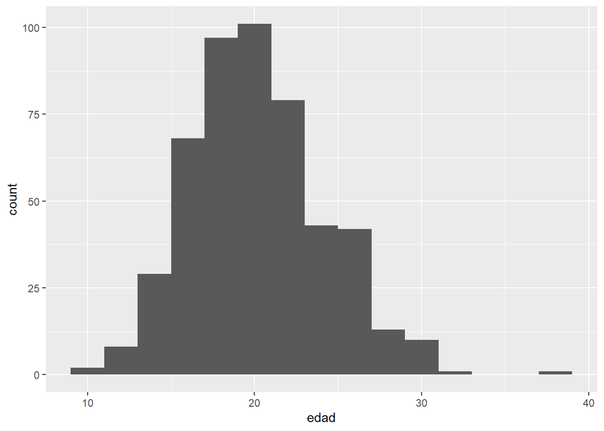

```r
hist_varF <- ggplot(data = subset(nadadoresParticipantes,gender== 'F')) +
geom_histogram(mapping = aes(x = edad), binwidth = 2)

hist_varM <- ggplot(data = subset(nadadoresParticipantes,gender== 'M'))+
geom_histogram(mapping = aes(x = edad), binwidth = 2)
hist_varF
```

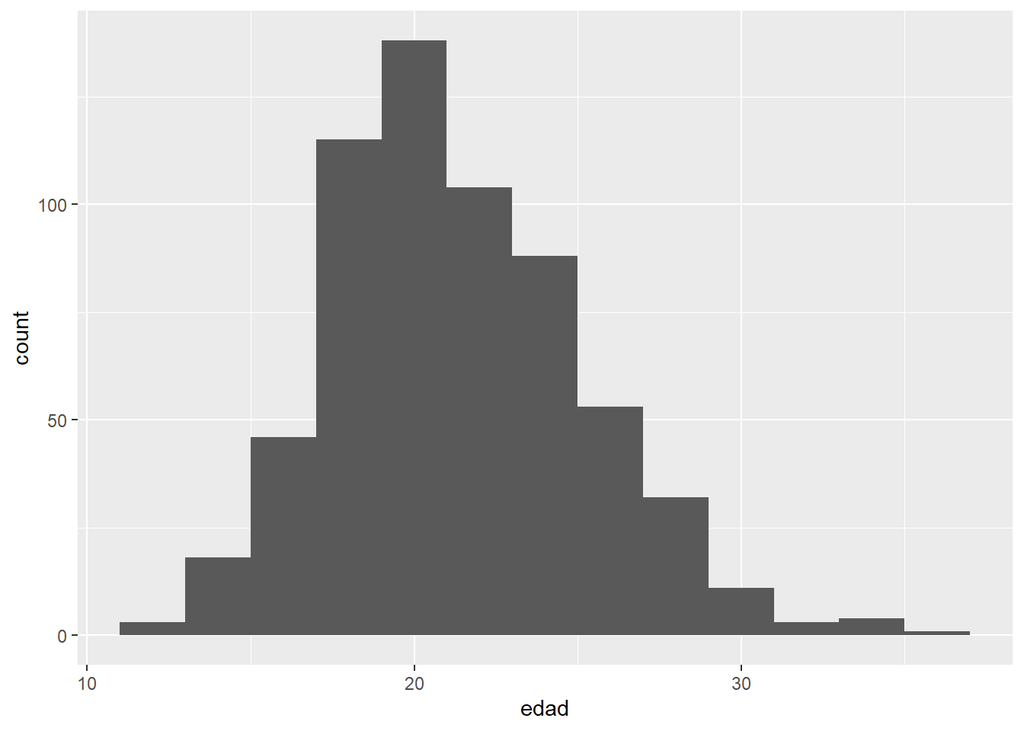

```r
hist_varM
```

Como podemos observar, la media de edades tiende a ser la misma en ambos géneros. Sin embargo, se puede observar como parece ocurrir que las mujeres comienzan a competir a menor edad.

### Nacionalidades.

Veamos un resumen de los datos sobre nacionalidades:

```r
summary(nadadoresParticipantes$name)
```

```
##                    China            United States                    Italy
##                       39                       37                       31
##                   Russia                Australia                  Germany
##                       30                       29                       27
##            Great Britain                   Brazil                    Japan
##                       25                       23                       23
##                   France                   Canada                  Hungary
##                       22                       19                       16
##                   Poland           Czech Republic                   Mexico
##                       16                       13                       13
##                   Greece                   Turkey                Venezuela
##                       12                       12                       12
##                  Finland                    Spain              Switzerland
##                       11                       11                       11
##                  Belarus                   Israel              Netherlands
##                       10                       10                       10
##                   Serbia                 Slovenia                   Sweden
##                       10                       10                       10
##                  Austria                  Denmark                    Egypt
##                        9                        9                        9
##                    Korea                Singapore                 Colombia
##                        9                        9                        8
##                  Estonia                Lithuania                 Malaysia
##                        8                        8                        8
##              New Zealand                 Thailand                  Belgium
##                        8                        8                        7
##           Chinese Taipei                Hong Kong                 Slovakia
##                        7                        7                        7
##                  Ukraine               Uzbekistan                Argentina
##                        7                        7                        6
##                    India                Indonesia                   Jordan
##                        6                        6                        6
##               Luxembourg                  Bahamas                 Bulgaria
##                        6                        5                        5
##                  Croatia                  Iceland                   Kuwait
##                        5                        5                        5
##                   Latvia                  Moldova                 Paraguay
##                        5                        5                        5
##                 Portugal             South Africa                  Vietnam
##                        5                        5                        5
```

[output cut: 13 more lines]

```
##                        4                        4                        4
##                    Kenya                   Kosovo               Kyrgyzstan
##                        4                        4                        4
##                  Lebanon                    Macau                 Maldives
##                        4                        4                        4
##                    Malta                 Mongolia               Mozambique
##                        4                        4                        4
##                  Namibia                    Nepal Northern Mariana Islands
##                        4                        4                        4
##                 Pakistan         Papua New Guinea                     Peru
##                        4                        4                        4
##              Philippines                  Romania                   Rwanda
##                        4                        4                        4
##                  (Other)
##                      242
```

Luego observamos que China fue la que más participantes llevó, con un total de 39, EEUU llevó 37 nadadores, Italia cierra el podio con 31 nadadores inscritos.

## Estudio sobre los eventos, reactiontime, lane, heats y daytime:

Primeramente, vamos a elaborar una tabla que refleje nadadores y pruebas nadadas (lo único que vamos a desechar son los parciales (filas) en caso de que la prueba sea de más de 50 metros.)

Para ello, primeramente debemos saber si cada prueba y cada tipo de prueba (preliminar, final o seminifinal), tiene un id de evento distinto, para ello seleccionamos algún nadador que haya nadado en la misma prueba varias rondas:

```r
ejemplo<-datos2015[datos2015$distance == 100 & datos2015$stroke=="BACK" & datos2015$code=="AUS", ]
head(ejemplo,6)
```

```
##     athleteid lastname firstname  birthdate gender      name code eventid heat
## 280    100529   LARKIN  MITCHELL 1993-07-09      M Australia  AUS      10    6
## 281    100529   LARKIN  MITCHELL 1993-07-09      M Australia  AUS      10    6
## 282    100529   LARKIN  MITCHELL 1993-07-09      M Australia  AUS     210    2
## 283    100529   LARKIN  MITCHELL 1993-07-09      M Australia  AUS     210    2
## 284    100529   LARKIN  MITCHELL 1993-07-09      M Australia  AUS     110    1
## 285    100529   LARKIN  MITCHELL 1993-07-09      M Australia  AUS     110    1
##     lane points reactiontime swimtime split cumswimtime splitdistance daytime
## 280    5    968         0.59    52.50     1       25.34            50     949
## 281    5    968         0.59    52.50     2       52.50           100     949
## 282    4    975         0.67    52.38     1       25.28            50    1748
## 283    4    975         0.67    52.38     2       52.38           100    1748
## 284    4    973         0.57    52.40     1       25.41            50    1836
## 285    4    973         0.57    52.40     2       52.40           100    1836
##     round distance relaycount stroke splitswimtime edad
## 280   PRE      100          1   BACK         25.34   22
## 281   PRE      100          1   BACK         27.16   22
## 282   SEM      100          1   BACK         25.28   22
## 283   SEM      100          1   BACK         27.10   22
## 284   FIN      100          1   BACK         25.41   22
## 285   FIN      100          1   BACK         26.99   22
```

Bien, vemos que el australiano nadó tanto las preliminares, como las semifinales como la final y el eventid era distinto, luego parece que podemos seguir con nuestro estudio:

```r
nadadoresPruebas <- datos2015 %>%
  distinct(eventid, athleteid, .keep_all = TRUE)
```

Los datos creados, reflejan nadadores y pruebas nadadas.

### Prueba 800m Libre femenino:

Veamos qué nadadores nadaron el 800 libre femenino:

```r
nadadoras800free<-nadadoresPruebas[nadadoresPruebas$distance==800 & nadadoresPruebas$gender=="F", ]

dim(nadadoras800free)
```

```
## [1] 52 23
```

### reactiontime

Veamos cómo se distribuyen los datos de tiempo de reacción de todos los nadadores:

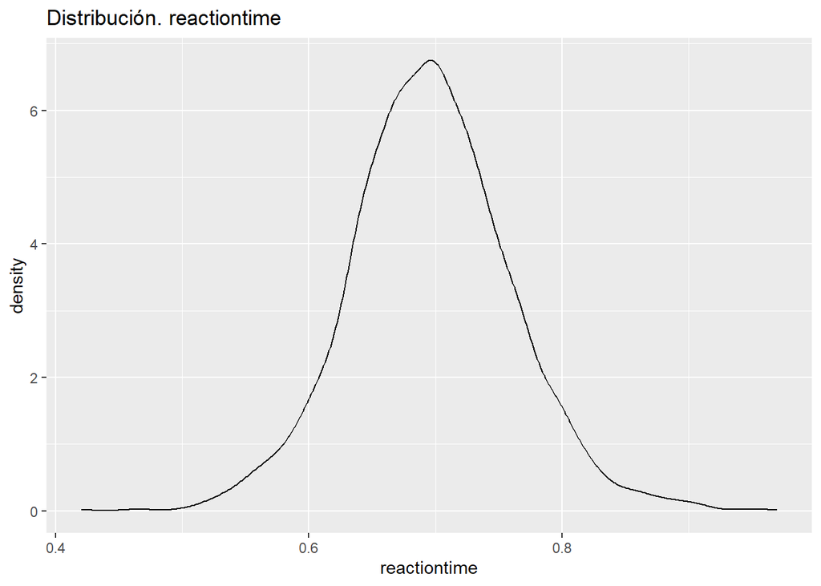

```r
ggplot(nadadoresPruebas, aes(x = reactiontime)) +
geom_density() +
ggtitle("Distribución. reactiontime")
```

Parece que los datos siguen una distribución normal a priori. Vamos a ir más alla para intentar sacar conclusiones más profundas.

Vamos a comparar ahora las funciones de densidad de las chicas en la prueba de 800m libres y 50m libres:

Primeramente calculamos el conjunto de datos del 50m libres femenino:

```r
nadadoras50free<-nadadoresPruebas[nadadoresPruebas$distance==50 & nadadoresPruebas$gender=="F" & nadadoresPruebas$stroke=="FREE", ]
```

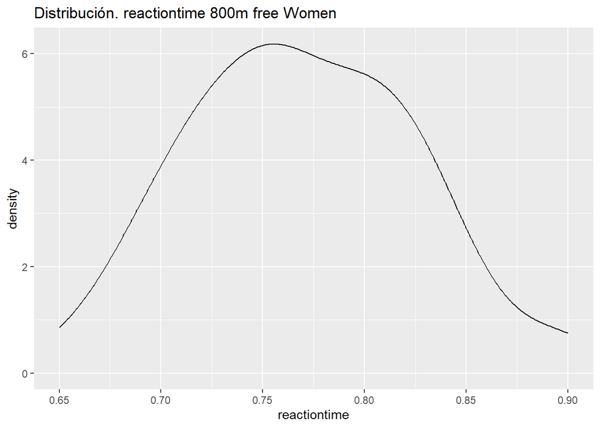

```r
ggplot(nadadoras800free, aes(x = reactiontime)) +
geom_density() +
ggtitle("Distribución. reactiontime 800m free Women")
```

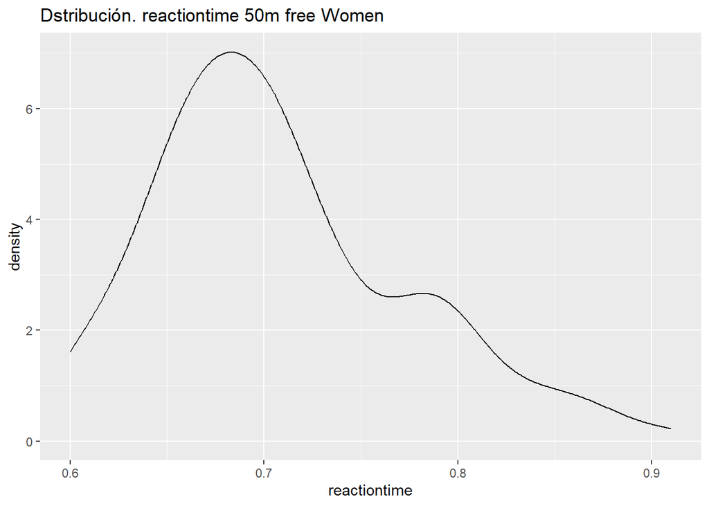

```r
ggplot(nadadoras50free, aes(x=reactiontime))+geom_density()+ggtitle("Dstribución. reactiontime 50m free Women")
```

Se observa cómo en la prueba de 50 hay más nadadoras que tarden menos de 0.7 que en la de 800m.

*Podemos comparar a los chicos para ver si es cierto lo supuesto*

### Calles usadas

Veamos cómo se distribuyen las calles usadas:

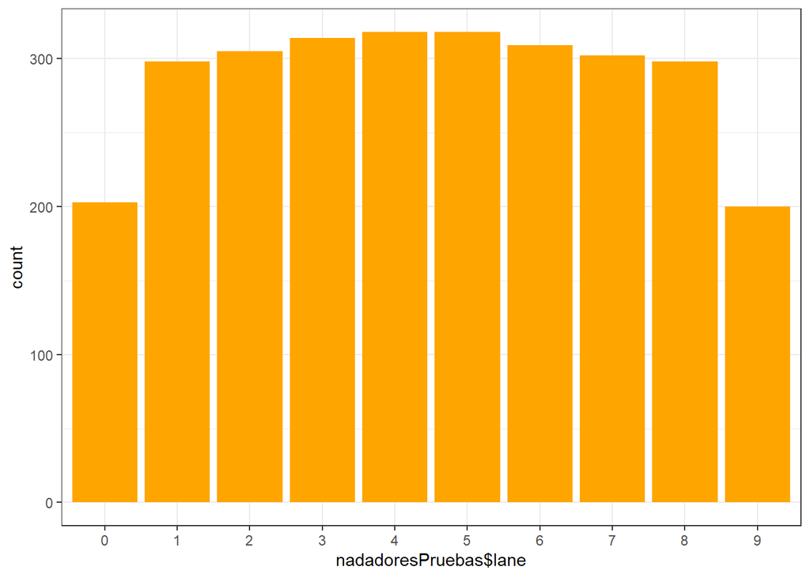

```r
ggplot(nadadoresPruebas, aes(nadadoresPruebas$lane)) + geom_bar(fill = "orange") +
theme_bw()
```

Se observa que las calles menos usadas son tanto la 0 como la 9.

### Points

Veamos ahora cómo se distribuyen los puntos:

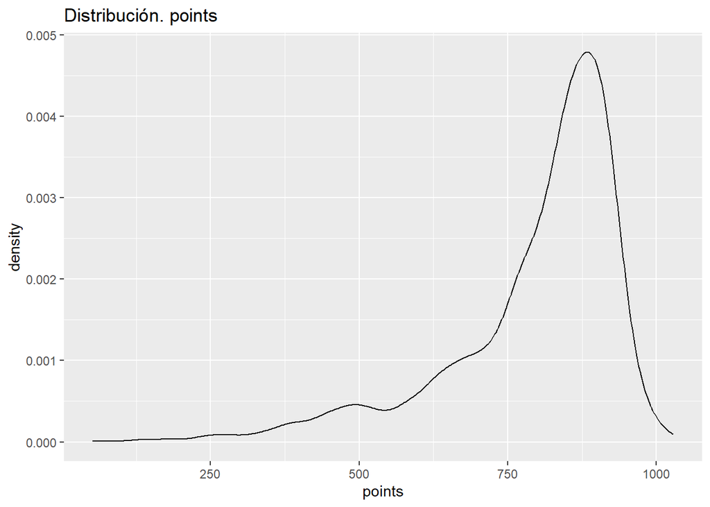

```r
ggplot(nadadoresPruebas, aes(x = points)) +
geom_density() +
ggtitle("Distribución. points")
```

Observamos que la mayoría de puntos se encuentran a partir de los 750/800 puntos, y esto, tiene sentido si razonamos que para entrar a los mundiales de natación, se necesitan unas marcas mínimas (una cantidad de puntos preestablecida). Luego es normal encontrar una gran cantidad de datos que tengan más de 750 puntos ya que había un “corte” para la inscripción en la competición. Esto hace que la gráfica no esté más distribuida por todos los posibles valores de puntos.

### Daytime

Nos genera curiosidad, por su formato, cómo se distribuye daytime, luego veamos:

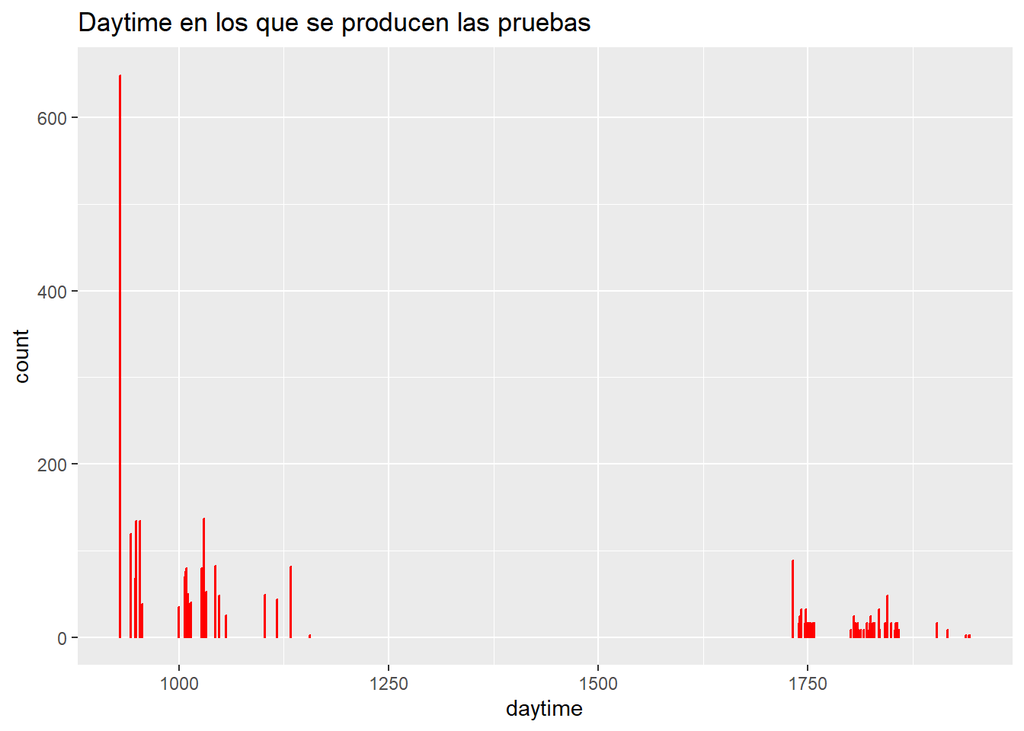

```r
ggplot(nadadoresPruebas, aes(daytime)) + geom_bar(width=0.5, colour="red", fill="skyblue") + ggtitle("Daytime en los que se producen las pruebas")
```

#PCA’s

Realizaremos ahora el análisis de componentes principales del 800m libres femenino:

## PCA. 800M libres femenino

Lo primero que debemos hacer es cargar los datos:

```r
prueba800libresPreliminar<- datos2015[datos2015$distance==800 & datos2015$gender=="F" & datos2015$stroke=="FREE" & datos2015$round=="PRE", ]

prueba800libresPreliminar <- prueba800libresPreliminar %>%
    select(lastname,firstname,gender, reactiontime, splitdistance, splitswimtime, edad, swimtime)
```

Bien, ahora, debemos encontrar la manera de crear una tabla en la que nos quedemos con el nombre, apellido y parciales

```r
pruebawide <- prueba800libresPreliminar %>%
  pivot_wider(names_from = splitdistance,       # Los valores de 'Split' serán los nombres de las columnas
              values_from =splitswimtime)     # Los valores de 'Tiempo' llenarán las celdas
View(pruebawide)
```

Lo tenemos!